# Índice de Desarrollo Humano

## 6. Tendencia del IDH a lo Largo del Tiempo

Este gráfico de líneas muestra la evolución del IDH para cada país a lo largo de los años.

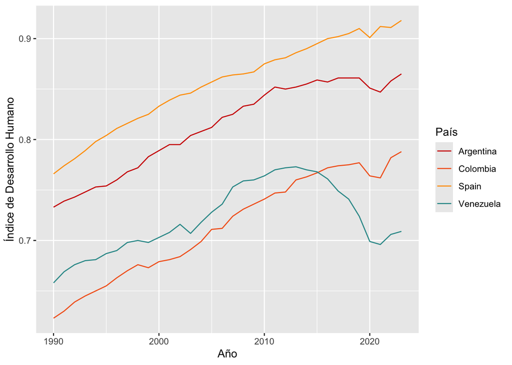

**Tendencia General:** Todos los países muestran una tendencia general al alza en su IDH desde 1990 hasta al menos la década de 2010, lo que indica un progreso en desarrollo humano. Y todos presentan una pequeña baja por 2020, lo cual puede ser debido a la pandemia.

# Tabla Resumen: Máximo IDH por País

Esta tabla resume el valor máximo del Índice de Desarrollo Humano alcanzado por cada país y el año en que se logró.

**Máximo Índice de Desarrollo Humano (IDH) por País**

Valores máximos alcanzados por cada entidad y el año correspondiente.

| País | Año del Máximo IDH | Máximo IDH |
| --- | --- | --- |
| Argentina | 2023 | 0.865 |
| Colombia | 2023 | 0.788 |
| Spain | 2023 | 0.918 |
| Venezuela | 2013 | 0.773 |

# Conclusión

Mientras que España y Argentina demuestran estabilidad y alto desarrollo, y Colombia un progreso continuo, Venezuela se distingue por una dramática regresión en el IDH en la última década.

En definitiva, los gráficos pintan un cuadro de éxito y progreso para España, Argentina y Colombia, pero revelan una *crisis humanitaria* y *de desarrollo sin precedentes* *en Venezuela*, donde el retroceso es tan significativo que ha creado una bifurcación histórica en los valores de su Índice de Desarrollo Humano.

*La personalización de los gráficos fue realizada con la ayuda del LLM “Gemini” en base al trabajo de mitad de curso.*

*La elaboración de la última tabla y de los análisis también contó con la asistencia del LLM “Gemini”.*